# Analysis FIT Experiment 2021

Paulsen, Schillig, Schlott, Timm

8/3/2021

## Loading needed packages

```r
library('tidyverse')
library('bootstrap')
library('lme4')

library(sjPlot)
library(sjmisc)
library(sjlabelled)
```

## Loading & tidying experimental data

After loading in the data obtained directly from the _magpie server, a couple of operations were performed to tidy the dataset. The column “condition” was transferred to two columns named “condition” containing the two factors conjunction and feature. The column “subcondition” includes the factor conjunction as well, but divides feature up into “color” and “shape” for a more detailed look further down in the analysis. This step is also useful to compare our results to the original paper’s analysis and corresponding graphs.

```r
# read in data sets that are seperate due to complications in the experimental setup. This will be resolved until the final hand-in.
data = readr::read_csv('./data/fit2021_results_total.csv')
data$precondition[data$condition=="color"]       <- "feature"
data$precondition[data$condition=="shape"]       <- "feature"
data$precondition[data$condition=="conjunction"] <- "conjunction"

# select all needed columns
data = subset(data, select=c(submission_id, trial_number, trial_type, precondition, condition, item, expected, number_of_items, correctness, RT, age, gender, education))
# rename the falsely named column education to dominant hand
names(data)[names(data) == 'education']       <- 'dominantHand'
names(data)[names(data) == 'number_of_items'] <- 'displaySize'
names(data)[names(data) == 'submission_id']   <- 'subject'
names(data)[names(data) == 'condition']       <- 'subcondition'
names(data)[names(data) == 'precondition']    <- 'condition'

## CONDITION
# pipe data to only include main trials and set the 2 ordered factors "feature" & "conjunction"
data <- data %>%
  filter(trial_type == "main") %>%
  mutate(condition = factor(condition, ordered = F, levels = c('feature', 'conjunction'))) %>%
## SUBCONDITION
# set the 3 ordered factors "color", "shape" & "conjunction" in the column "subcondition"
  mutate(subcondition = factor(subcondition, ordered = F, levels = c('conjunction', 'color', 'shape')))


data
```

```
## # A tibble: 7,680 × 13
##    subject trial_number trial_type condition   subcondition  item expected
##      <dbl>        <dbl> <chr>      <fct>       <fct>        <dbl> <chr>
##  1    3221            1 main       conjunction conjunction    207 target
##  2    3221            2 main       conjunction conjunction    155 target
##  3    3221            3 main       conjunction conjunction    176 target
##  4    3221            4 main       conjunction conjunction    174 target
##  5    3221            5 main       conjunction conjunction    161 no target
##  6    3221            6 main       conjunction conjunction    205 target
##  7    3221            7 main       conjunction conjunction    211 no target
##  8    3221            8 main       conjunction conjunction    214 no target
##  9    3221            9 main       conjunction conjunction    215 no target
## 10    3221           10 main       conjunction conjunction    177 no target
## # … with 7,670 more rows, and 6 more variables: displaySize <dbl>,
## #   correctness <chr>, RT <dbl>, age <dbl>, gender <chr>, dominantHand <chr>
```

## Population Statistics

We are extracting some general statistics about our participant population.

```r
data %>%
  mutate(gender = factor(gender, ordered = F, levels = c('male', 'female'))) %>%
  group_by(gender) %>%
  summarize(meanAge = mean(age)) %>%
  ungroup()
```

```
## # A tibble: 2 × 2
##   gender meanAge
##   <fct>    <dbl>
## 1 male      26.4
## 2 female    24.5
```

```r
data %>%
  mutate(gender = factor(gender, ordered = F, levels = c('male', 'female'))) %>%
  group_by(subject) %>%
  summarize(gender = unique(gender)) %>%
  group_by(gender) %>%
  summarize(numGen = n()) %>%
  ungroup()
```

```
## # A tibble: 2 × 2
##   gender numGen
##   <fct>   <int>
## 1 male        5
## 2 female     15
```

## Confidence Intervals

The tidy dataset is now used to calculate mean reaction times (RT) for each combination of expected (target,no target), displaySize(1, 5, 15, 30), and condition (conjunction, feature). This process was repeated analogously for the subcondition (conjunction, color, shape). In addition to the mean reaction times, 95% confidence intervals of the mean were calculated by bootstrapping 2000 samples of the mean in each condition-combination.

A quick aside: The bootstrap() throws an error when the input vector (RT in our case) contains duplicates. We have been able to reproduce this with with vectors from other projects and have sent in a bug report to the authors of the package. To solve this problem here, we have chosen to use the unique() function to strip our RT of said duplicates. While we are aware that this impacts the total number of RTs in the vector, the solution doesn’t seem to impact the results in a problematic manner.

```r
# Compute the RT 95% confidence intervals for each subject using the bootstrap package
ci_condition = data %>% group_by(expected, displaySize, condition) %>%
  summarize(meanRT = mean(RT),
            minCI = mean(bootstrap(unique(RT), 2000, theta = function(x) {mean(x)}, func = function(x) {quantile(x,.025)})$jack.boot.val),
            maxCI = mean(bootstrap(unique(RT), 2000, theta = function(x) {mean(x)}, func = function(x) {quantile(x,.975)})$jack.boot.val),
            ) %>%
  ungroup() %>%
  mutate(expected = factor(expected))
# Compute the RT 95% confidence intervals for each subject using the bootstrap package
ci_subcondition = data %>% group_by(expected, displaySize, subcondition) %>%
  summarize(meanRT = mean(RT),
            minCI = mean(bootstrap(unique(RT), 2000, theta = function(x) {mean(x)}, func = function(x) {quantile(x,.025)})$jack.boot.val),
            maxCI = mean(bootstrap(unique(RT), 2000, theta = function(x) {mean(x)}, func = function(x) {quantile(x,.975)})$jack.boot.val)) %>%
  ungroup() %>%
  mutate(expected = factor(expected))
ci_condition
```

```
## # A tibble: 16 × 6
##    expected  displaySize condition   meanRT minCI maxCI
##    <fct>           <dbl> <fct>        <dbl> <dbl> <dbl>
##  1 no target           1 feature      1095. 1090. 1208.
##  2 no target           1 conjunction   996.  997. 1115.
##  3 no target           5 feature      1115. 1102. 1199.
##  4 no target           5 conjunction  1060. 1043. 1152.
##  5 no target          15 feature      1429. 1401. 1529.
##  6 no target          15 conjunction  1530. 1440. 1794.
##  7 no target          30 feature      1707. 1657. 1812.
##  8 no target          30 conjunction  2106. 2038. 2183.
##  9 target              1 feature       966.  957. 1056.
## 10 target              1 conjunction   900.  837. 1223.
## 11 target              5 feature      1022. 1023. 1139.
## 12 target              5 conjunction   945.  945. 1033.
## 13 target             15 feature      1031. 1024. 1138.
## 14 target             15 conjunction  1088. 1075. 1150.
## 15 target             30 feature      1059. 1053. 1167.
## 16 target             30 conjunction  1473. 1441. 1553.
```

```r
ci_subcondition
```

```
## # A tibble: 24 × 6
##    expected  displaySize subcondition meanRT minCI maxCI
##    <fct>           <dbl> <fct>         <dbl> <dbl> <dbl>
##  1 no target           1 conjunction    996.  997. 1113.
##  2 no target           1 color         1115. 1068. 1237.
##  3 no target           1 shape         1076. 1037. 1158.
##  4 no target           5 conjunction   1060. 1045. 1151.
##  5 no target           5 color         1126. 1080. 1207.
##  6 no target           5 shape         1104. 1073. 1182.
##  7 no target          15 conjunction   1530. 1440. 1795.
##  8 no target          15 color         1443. 1372. 1536.
##  9 no target          15 shape         1414. 1351. 1520.
## 10 no target          30 conjunction   2106. 2040. 2180.
## # … with 14 more rows
```

## Plotting Conditions (Feature, Conjunction)

Moving on to the first visualization of the data we are here plotting the mean reaction times against displaySize whilst showing the confidence intervals as error-bars. Since reaction times are not normally distributed (leftward skew & left-limited to zero) we have chosen to transform it using the log function. This decision is backed by the paper To transform or not to transform: using generalized linear mixed models to analyse reaction time data by Lo S and Andrews S (2015). While this transformation is primarily useful in the general linear regression model following these plots, we have chosen to already plot the log(RT) in this step for ease of comparison and overall consistency.

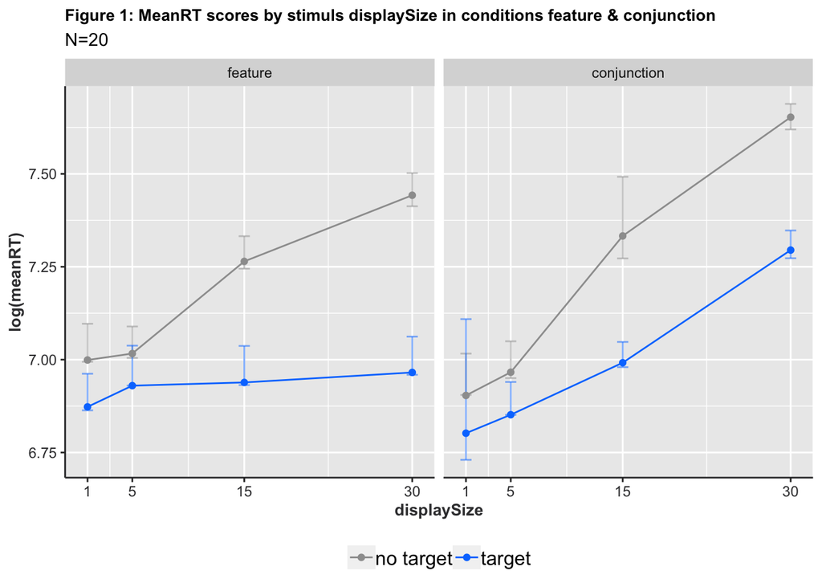

```r
# Plot meanRTs with respect to displaySize
ggplot(ci_condition, aes(y = log(meanRT), x = displaySize, color = expected)) +
  geom_errorbar(aes(ymin = log(minCI), ymax = log(maxCI)), width=1, alpha = 0.5) +
  geom_point()  + geom_line() +
  facet_grid(~ condition) +
  scale_color_manual(values=c("8e8e93", "#007bff")) +
  scale_x_continuous(breaks = c(1,5,15,30)) +
  ggtitle("Figure 1: MeanRT scores by stimuls displaySize in conditions feature & conjunction",
          subtitle = paste0("N=", nrow(unique(data["subject"])))) +
  theme(legend.position = "bottom",
        axis.line = element_line(color = "#3a3a3c"),
        legend.key.height = unit(1,"line"),
        legend.title = element_text(size = 0, face = "bold"),
        legend.text = element_text(size = 12),
        legend.background = element_rect(fill = "transparent"),
        axis.text = element_text(size = 9, color = "#3a3a3c"),
        axis.title = element_text(size = 10, face = "bold", color = "#3a3a3c"),
        plot.title = element_text(size = 10, face = "bold"))
```

*Figure 1* shows the log mean reaction times (log(meanRT) and their 95% confidence intervals (errorbars) with respect to the present displaySize of the stimulus (1, 5, 15 or 30 letters on screen) in both feature and conjunction condition. It is visible that within both conditions the reaction times including the target (blue) were consistently lower than the ones without the target (grey). Both conditions show a linear increase of reaction time without a target present with a steeper increase in the conjunction condition compared to the feature condition. In the feature condition the increase seems to be almost completely extinguished when a target is present (feature, blue line), while it is still present in the conjunction condition (conjunction, blue line).

## Plotting Subcondtions (Color, Shape, Conjuction)

With the second visualization we are trying to achieve a very similar plot to Figure 1 in the original Treisman & Gelade Paper we are attempting to replicate here. The original figure also plots reaction time against display size, while keeping both conditions and their subconditions in one plot. While the 1980 figure only distinctly plots the subcategories color & shape when a target is present (blue dashed and dotted lines), ggplot is forcing us to make the distinction throughout both target-conditions. Since this figure is meant to be directly comparable no logarithmic transformation of the RTs was performed.

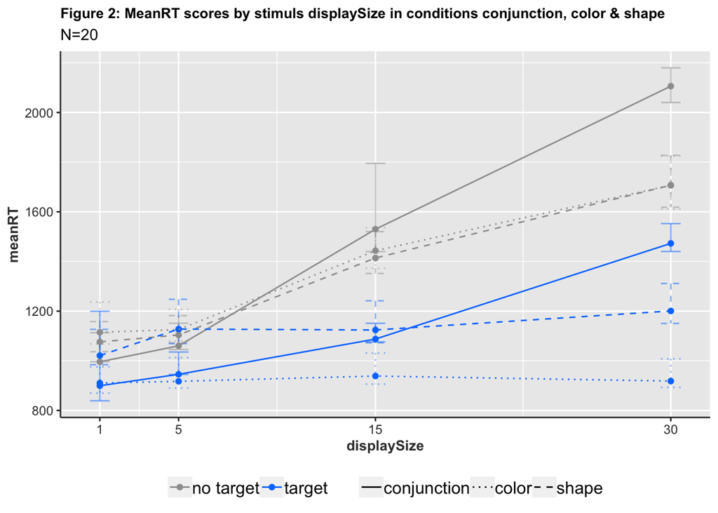

```r
# Plot meanRTs with respect to displaySize
ggplot(ci_subcondition, aes(y = meanRT, x = displaySize, color = expected, linetype = subcondition)) +
  geom_errorbar(aes(ymin = minCI, ymax = maxCI), width=1, alpha = 0.5) +
  geom_point()  + geom_line() +
  scale_color_manual(values=c("8e8e93", "#007bff")) +
  scale_linetype_manual(values=c("solid", "dotted", "dashed")) +
  scale_x_continuous(breaks = c(1,5,15,30)) +
  ggtitle("Figure 2: MeanRT scores by stimuls displaySize in conditions conjunction, color & shape",
          subtitle = paste0("N=", nrow(unique(data["subject"])))) +
  theme(legend.position = "bottom",
        axis.line = element_line(color = "#3a3a3c"),
        legend.key.height = unit(1,"line"),
        legend.title = element_text(size = 0, face = "bold"),
        legend.text = element_text(size = 12),
        legend.background = element_rect(fill = "transparent"),
        axis.text = element_text(size = 9, color = "#3a3a3c"),
        axis.title = element_text(size = 10, face = "bold", color = "#3a3a3c"),
        plot.title = element_text(size = 10, face = "bold"))
```

## Statistical significance test

We have chosen to run a simple significance test using a general linear model testing the hypothesis that the reaction times are linearly dependent on the condition and displaySize as well as their interaction. Feature Integration Theory states, that displaySize should have a bigger influence on RTs in the conjunction condition than in the feature (color, shape) condition. For this we perform a linear regression on the data filtered to the conditions where a target is present.

```r
model_conditions = glm(log(RT) ~ condition + displaySize + displaySize:condition, data = filter(data, expected == "target" ))
tab_model(model_conditions)
```

|  | log(RT) |  |  |
| --- | --- | --- | --- |
| Predictors | Estimates | CI | p |
| (Intercept) | 6.81 | 6.79 – 6.84 | **<0.001** |
| condition [conjunction] | -0.14 | -0.18 – -0.11 | **<0.001** |
| displaySize | 0.00 | 0.00 – 0.00 | **<0.001** |
| condition [conjunction] * displaySize | 0.02 | 0.01 – 0.02 | **<0.001** |
| Observations | 3840 |  |  |
| R<sup>2</sup> | -1.913 |  |  |

$$Model:\\
log(RT) = + 6.81 - 0.14 * condition[conjunction] + 0.00 * displaySize + 0.02 * condition[conjunction] * displaySize$$
The outcome of this general linear model is to be read as follows: With the feature condition as our baseline condition the intercept is at 6.81 log(RT) with an influence of 0.00 by increasing the displaySize. Both of these observations are statistically significant based on their p-values below 0.001. In the conjunction condition (mathematically set to 0 in the feature condtion, set to 1 in the conjunction condition) the intercept is attenueted by -0.14 and the displaySize now has an effect of increasing log(RT) by 0.02 for every single step increase in displaySize. Both of these observations are statistically significant based on their p-values below 0.001.

# Sources

2021 Lüdecke, Daniel - Summary of Regression Models as HTML Table https://cran.r-project.org/web/packages/sjPlot/vignettes/tab_model_estimates.html

Lo S and Andrews S (2015) To transform or not to transform: using generalized linear mixed models to analyse reaction time data. Front. Psychol. 6:1171. doi: 10.3389/fpsyg.2015.01171